# Introduction to Equilibrium

March, 2025

## Introduction to Equilibrium

- **Equilibrium**: A state of balance in a system, where opposing forces or processes are in balance.
- At equilibrium, the system’s state does not change over time: \(\frac{d}{dt} f(t) = 0\).
- **Stable Equilibrium**: A system returns to its equilibrium state after a small perturbation.
- **Unstable Equilibrium**: A system moves away from its equilibrium state after a small perturbation.

## Stable Equilibrium Example

- **Example:** you pour hot coffee into a cup, will it stay hot, get hotter, or cool toward room temperature?
- **Equation**: \(\frac{dT}{dt} = k(T - T_{\text{env}})\), where \(T\) is the temperature of the object, \(T_{\text{env}}\) is the ambient (environmental) temperature, and \(k\) is a constant related to the cooling or heating efficiency.
- **Exact Solution**: \(T(t) = T_{\text{env}} + (T(0) - T_{\text{env}})e^{kt}\), where \(T(0)\) is the initial temperature of the object.

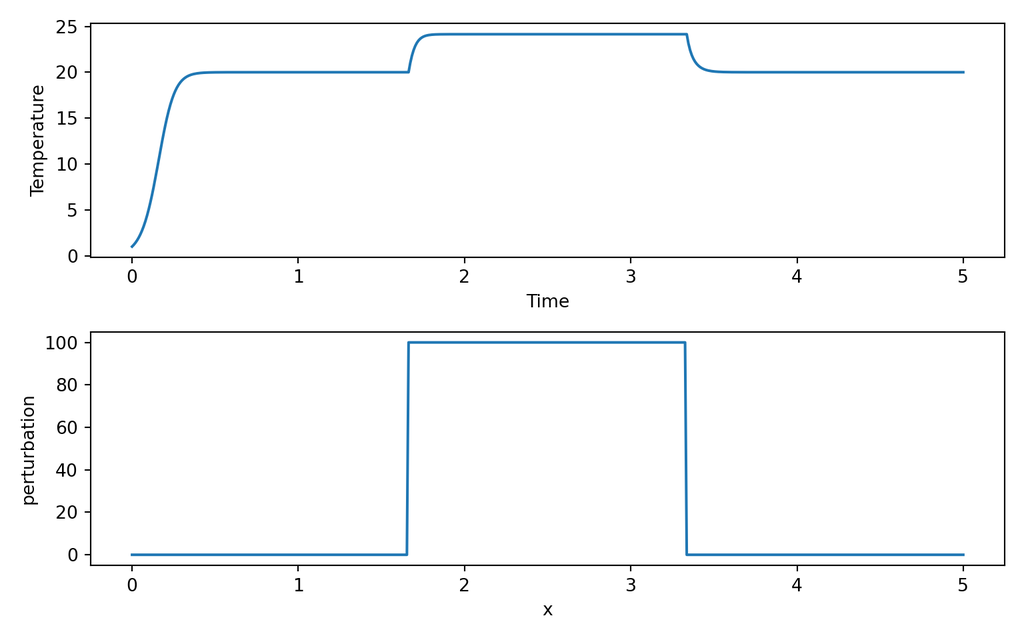

## Unstable Equilibrium Example

- **Example:** Exponential population growth or radioactive decay
- **Equation**: \(\frac{dy}{dx} = ky\), where \(k\) is a constant.
- **Exact Solution**: \(y(x) = y(0)e^{kx}\), where \(y(0)\) is the initial condition.

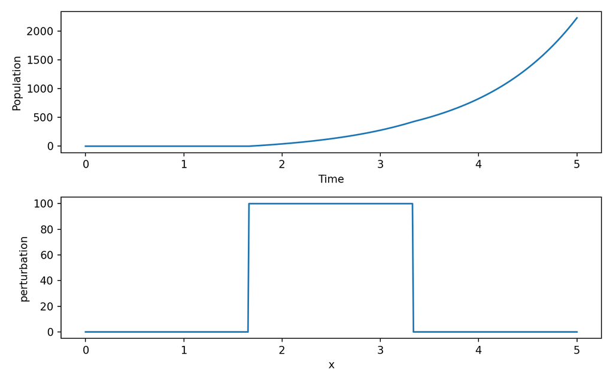

## Question

Does this system have an equilibrium and if so is it stable or unstable?

## Answer

**Answer**

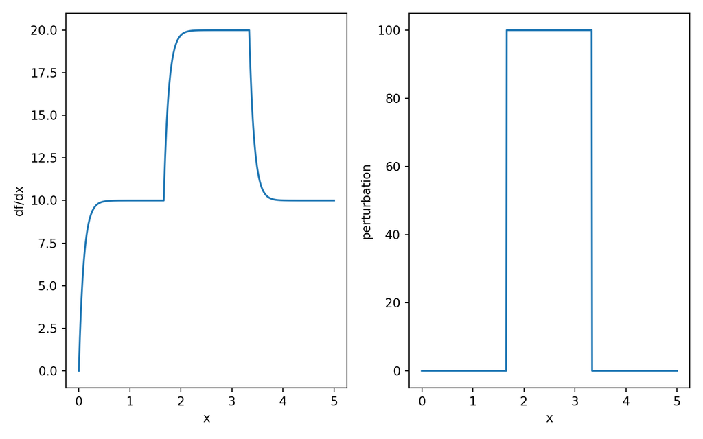